# The Hidden Cost of Bananas: The Effects of Pesticides on Newborns’ Health

Replication Report | Environmental and Urban Economics | Prof.: Sophie Mattes

Vinícius Hector and Natália Trigo [FGV EPGE]

March, 2024

# Introduction

- Increasing demand for agricultural productions, combined with land restrictions and changing weather has contribuited to the extensive use of agrochemicals
- Issue:This use of chemicals has severe negative effects on the populations living close to the farms or working on them
- But, still there are few studies analyzing the effects of enviromental pollution on health outcomes
- very few that leverage quasi-experimental variation to estimate the health effects of the use of pesticides in agriculture
- Goal of this paper: examine the effects of pesticides used in banana plantations in Ecuador on newborn’s health outcomes

# Empirical Strategy

- DiD approach that exploits the seasonal changes in the fumigation of banana plantations as an identification strategy
- 4 newborn’s health outcomes: weight at birth, gestational length, low birth weight, and preterm
- Use of mother’s address durirng pregancy and precise information on the perimeter of the plantations to compute measures of exposure to air pollution
- Compute the mother’s distance from the plantation and the area of fumigated plantations near their place of residence

$$Y_{ijmy} = \beta_{0} + \beta_{1}\text{Banana Exposure}_{ijmy} +
\beta_{2}\text{Intensive Fumigations}_{ijmy} + \\ \theta \text{Banana
Exposure}_{ijmy} \times \text{Intensive Fumigations}_{ijmy} + \\ \delta
X_{i} + \mu_{j} + \psi_{m} + \pi_{y} + \epsilon_{ijmy}$$

$$Y_{ijmy} = \beta_{0} + \beta_{1}\text{Banana Exposure}_{ijmy} +
\sum_{z=1}^{3} \beta_{z} Z^{th}\text{Intensive Fumigations}_{ijmy} +
\\ \sum_{z=1}^{3} \theta_{z} Z^{th}\text{Banana Exposure}_{ijmy}
\times Z^{th}\text{Intensive Fumigations}_{ijmy} + \\ \delta X_{i} +
\mu_{j} + \psi_{m} + \pi_{y} + \epsilon_{ijmy}$$

in which:

- $Y_{ijmy}$: birth outcomes of newborn $i$, in a grid cell $j$, month $m$ and year
- $\text{Banana Exposure}_{ijmy}$: is a dummy variable that takes the value 1 for newborns from mothers geographically exposed to pesticides
- $\text{Intensive Fumigations}_{ijmy}$: is a dummy variable that takes the value 1 for newbornds that were affected by intensive fumigations for at least theree months during gestation
- $Z^{th}\text{Intensive Fumigations}_{ijmy}$: is a dummy variable that takes the value 1 for the newbornds that were affected by intensive fumigations during the three months of the $Z^{th}$ gestation trimester.
- $X$: vector of controls

## Data

```r
## 1. Load Packages
library(tidyverse) # Easily Installand Load the 'Tidyverse'
library(lubridate) # Make Dealing with Dates a Little Easier
library(janitor) # Simple Tools for Examining and Cleaning Dirty Data
library(data.table) # Extension of `data.frame`
#library(tidylog) # Logging for 'dplyr' and 'tidyr' Functions
library(haven) # Open .xpt and Stata (.do) files
library(foreign) # Read and Write Data from Other Statistical Systems
library(Hmisc) # Harrell Miscellaneous. Used to extract .dta file label easily
library(htmltools) # Tools for HTML
library(lintr) # Trying to removing the annoying lint
library(gt) # Easily Create Presentation-Ready Display Tables
library(gtExtras) # Additional Functions to Enhance 'gt'
library(broom) # Convert Statistical Analysis Objects into Tidy Tibbles
library(boot) # Bootstrap Functions for R
library(lfe) # Linear Group Fixed Effects
library(sandwich) # For robust standard errors
library(lmtest) # For coefficient testing with robust standard errors
library(plm) # Panel Data Models - to perform OLS with FE
library(tidyr)
library(tidycat)
library(bife)
library(fixest)
library(multiwayvcov)
library(progress)
knitr::opts_chunk$set(fig.width=8, fig.height=8)
library(here)
bananas1.R <- read_dta("bananas1.dta") # Main dataset used on the papaer
bananas2.R <- read_dta("bananas2.dta") # Dataset used to generate the tables with maternal fixed effects
bananas1 <- bananas1.R %>% clean_names() # Clean the column names
bananas2 <- bananas2.R %>% clean_names() # Clean the column names
```

For **Newborn’s health**, the authors collected data from:

- dataset from the National Register of Live Births for the period 2015-17 (information on the mother’s residential addresses during pregancy)
- data set includes information on several observable characteristics of children and mothers On the other hand, the dataset containing information about **Ecuador’s banana plantations:** came from:
- 2013 agricultural census
- 2016-18 register of aerial fumigations (geocoded data on the application of the pesticide)

### Table 2

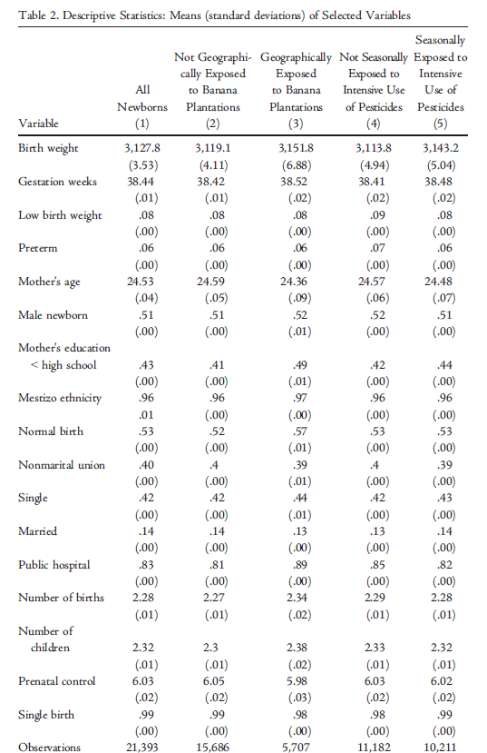

# Reduced Form estimations

Firstly, here is the setup used for the replication of the regressions:

```r
GetBananasVariableDescription <- function(dataset) {
    dataset_length <- dim(dataset)[2] # Get the number of rows
    dataset_labels <- sapply(dataset, function(column) attr(column, "label")) # Get the labels of the columns (its a messy list)
    dataset_types <- sapply(dataset, function(column) attr(column, "format.stata"))
    dataset_variables_description <- tibble(column_name = NA, label = NA, format = NA) # Create a tibble to store the variables description
    for (i in c(1:dataset_length)) {
        dataset_variables_description[i, 1] <- names(dataset[i])
        dataset_variables_description[i, 2] <- dataset_labels[[i]]
        dataset_variables_description[i, 3] <- dataset_types[[i]]
    } # complete the tibble with the variables description. First column: each name, second column: each label
    return(dataset_variables_description)
}

bananas1_variables_description <- GetBananasVariableDescription(bananas1)
bananas1_variables_description %>% print(n = 100)
```

```
## # A tibble: 68 × 3
##    column_name label                                                      format
##    <chr>       <chr>                                                      <chr>
##  1 sex         Newborn's sex                                              %8.0g
##  2 weight      Birth weight                                               %8.0g
##  3 gweeks      Gestation weeks                                            %8.0g
##  4 tlabor      Type of labor                                              %8.0g
##  5 nbl         Number of babies from labor                                %8.0g
##  6 age         Mother's age                                               %8.0g
##  7 visits      Number of prenatal care visits                             %8.0g
##  8 labors      Number of previous labors                                  %8.0g
##  9 ethnic      Mother's ethnic group                                      %8.0g
## 10 marital     Marital status                                             %8.0g
## 11 dist        Distance to nearest banana plantation (meters)             %9.0g
## 12 nchild      Number of children                                         %9.0g
```

[output cut: 56 more lines]

```r
bananas2_variables_description <- GetBananasVariableDescription(bananas2)
#bananas3_variables_description <- GetBananasVariableDescription(bananas3)

# Make relevant discrete variables as factors
bananas1$marital <- as.factor(bananas1$marital)
bananas1$ethnic <- as.factor(bananas1$ethnic)
bananas1$grid <- as.factor(bananas1$grid)
bananas1$cohort <- as.factor(bananas1$cohort)

bananas2$marital <- as.factor(bananas2$marital)
bananas2$ethnic <- as.factor(bananas2$ethnic)
bananas2$grid <- as.factor(bananas2$grid)
bananas2$cohort <- as.factor(bananas2$cohort)
bananas2$mfeid <- as.factor(bananas2$mfeid)
bananas2 <- bananas2 %>%
    mutate(mfeid_grid = interaction(mfeid, grid)) %>%
    drop_na(mfeid_grid) # Create a new variable that is the interaction between the maternal fixed effect and the grid to be used on table 5

no_bootstraps = 100
```

Secondly, we’ve created some useful functions. These functions will be called on the regression codes.

```r
## 3. Set up functions

### 3.1. Given a dataset with cluster specified, this returns a list with a sample of replacement the size of the unique number of clusters
cluster_sample <- function(data, cluster_var) {
    cluster_list <- unique(data[[cluster_var]]) # List of unique clusters
    sample_size <- length(cluster_list) # Sample size = number of unique clusters (but the sample will have repetitions and non-apperences)

    cluster_sample <- sample(cluster_list, sample_size, replace = TRUE) # Sample of the clusters with
    return(cluster_sample)
}

example1 <- cluster_sample(data = bananas1, cluster_var = "grid")
example1 # Return a list with lenght = 172 of a sample with replacement from the 172 possible clusters
```

```
##   [1] 27078 27087 23710 19440 23981 21678 26571 23879 21421 24842 23668 24491
##  [13] 27368 15933 20858 27077 25649 23930 19933 19658 24822 23353 23355 23949
##  [25] 23673 26284 24263 24219 23060 22787 22564 26282 23663 24518 24741 25324
##  [37] 19658 18292 24741 21636 23401 23959 26571 27077 19440 27087 13716 27368
##  [49] 23407 24822 21991 24836 19649 19420 25710 15933 22563 24836 24838 26282
##  [61] 27077 21390 27082 20858 27082 24234 19155 22836 23355 23060 23639 21638
##  [73] 22787 20849 23355 25643 24201 21678 18792 19708 19658 23632 19441 19155
##  [85] 21708 25710 20229 24487 23710 26571 23094 24842 19136 23663 24246 26225
##  [97] 24218 19647 24263 27082 24201 21102 19946 18581 21937 14577 18002 25425
## [109] 27077 23060 24455 23933 25409 18005 21708 25418 23915 19136 19714 23959
## [121] 20228 25425 27368 23121 23136 25418 21670 23136 23931 23643 23068 24836
## [133] 18005 27082 23931 23060 25710 21708 24218 27368 25711 22261 27368 23975
## [145] 25390 23382 23932 22519 24218 25346 19151 16567 19083 19658 23382 25409
## [157] 23122 18001 22261 23688 13429 24201 25363 23933 20228 14578 22836 23060
## [169] 22787 24246 24246 26512
## 172 Levels: 13429 13716 14577 14578 14864 15715 15719 15933 16002 ... 27371
```

```r
### 3.2. Given a dataset with cluster specified, this returns a shuffled dataset according to the sample of clusters. Notice that since a cluster may appear multiple times, entire chunks of rows from the original dataset will appear multiple times
boot_dataset <- function(data, cluster_var) {
    cluster_sample <- cluster_sample(data, cluster_var) # sample with repetitions of clusters

    boot_dataset <- data.frame() # Empty dataset
    for (i in 1:length(cluster_sample)) {
        temp_dataset <- data %>% filter(.[[cluster_var]] == cluster_sample[i]) # temp_dataset = dataset with rows for cluster_sample[i], there will be repetitions and non-apperences
        boot_dataset <- bind_rows(boot_dataset, temp_dataset) # Add the rows of the sample to the new dataset
    }
    return(boot_dataset) # It will be a dataset with different size from data. Since some clusters appear more than once, this will happern
}

example2 <- boot_dataset(bananas1, "grid")
tibble(example2) %>% head() # This looks like bananas1
```

```
## # A tibble: 6 × 68
##     sex weight gweeks tlabor   nbl   age visits labors ethnic marital  dist
##   <dbl>  <dbl>  <dbl>  <dbl> <dbl> <dbl>  <dbl>  <dbl> <fct>  <fct>   <dbl>
## 1     1   1820     32      1     1    21      8      1 6      1        668.
## 2     1   3400     38      1     1    19      4      2 6      2        668.
## 3     0   3620     39      0     1    16      9      1 6      1        668.
## 4     1   4390     38      1     1    18      5      1 6      2        668.
## 5     1   3100     38      0     1    20      4      2 6      2        634.
## 6     0   3450     38      0     1    29      6      7 6      1        634.
## # ℹ 57 more variables: nchild <dbl>, educ <dbl>, private <dbl>, area <dbl>,
## #   cohort <fct>, preterm <dbl>, lbw <dbl>, grid <fct>, pxt1_2 <dbl>,
## #   pxt2_2 <dbl>, pxt3_2 <dbl>, pxt1 <dbl>, pxt2 <dbl>, pxt3 <dbl>,
## #   pxp_2 <dbl>, pxp <dbl>, pxt1_lead <dbl>, pxt2_lead <dbl>, pxt3_lead <dbl>,
## #   pxp_lead <dbl>, pxt1_lag <dbl>, pxt2_lag <dbl>, pxt3_lag <dbl>,
## #   pxp_lag <dbl>, bx <dbl>, rxp5002 <dbl>, rxp5003 <dbl>, rxp7502 <dbl>,
## #   rxp7503 <dbl>, esample <dbl>, donut <dbl>, dethnic1 <dbl>, …
```

```r
dim(example2) # This has the same number os cols, but different number of rows
```

```
## [1] 12782    68
```

```r
### 3.3. Given data and model specification, this produces a model object that will be used on the bootsrapping itself
set_model <- function(data, dependent_var, independent_var, fixed_effects, remove_var, model_type) {
    # Common specifications for all regressions
    dependent_var_str <- dependent_var
    independent_var_str <- paste(independent_var, collapse = " + ")
    fixed_effects_str <- paste(fixed_effects, collapse = " + ")
    mom_controls <- c("age", "educ", "private", "labors", "nchild", "visits", "nbl", "sex", "tlabor", "marital")

    if (!is.null(remove_var) && length(remove_var) > 0) {
        mom_controls <- setdiff(mom_controls, remove_var)
    } # Remove the variable if it is in the mom_controls list, if not, remains the same

    mom_controls_str = paste(mom_controls, collapse = " + ")

    formula_str <- paste(dependent_var_str, "~", independent_var_str, "+", mom_controls_str, " | ", fixed_effects_str)
    formula <- as.formula(formula_str)
    print("MODEL FORMULA BELOW:")
    print(formula)

    if (model_type == "ols") {
        model <- felm(formula, data = data) # Fixed effects linear model
    } else if (model_type == "logit") {
        model <- feglm(formula, data = data, family = "logit") # Fixed effects logit model, returns estimates for the coefficients, not the odds ratio
    }
    return(model)
}
```

```r
### 3.4. Given original data and model specifications, this returns a 1 X n_coeficients dataframe with the estimates of the coefficients based on a clustered resample with repetition dataset
estimate_coefs <- function(data, dependent_var, independent_var, fixed_effects, remove_var, cluster_var, model_type) {
    boot_data <- boot_dataset(data, cluster_var) %>% tibble() # Make the boot dataset that will be used for one estiamtion
    boot_model <- set_model(boot_data, dependent_var, independent_var, fixed_effects, remove_var, model_type) # Fit the model

    estimates <- tidy(boot_model)
    estimates <- estimates %>% subset(select = c(term, estimate)) # Clean results
    estimates <- as.data.frame(t(estimates)) # Janitoring
    colnames(estimates) <- as.character(unlist(estimates[1, ])) # More janitoring
    estimates <- estimates[-1, ] # Remove the first row
    estimates <- estimates %>%
        tibble() %>%
        clean_names() # Final df is a 1 x n_coeficients df

    estimates[] <- estimates[] %>% lapply(function(x) as.numeric(as.character(x))) # Convert all to numeric
    return(estimates)
}

example4 <- estimate_coefs(
    data = bananas1,
    dependent_var = "weight",
    independent_var = c("bx", "ethnic"),
    fixed_effects = c("grid", "cohort"),
    remove_var = NA,
    cluster_var = "grid",
    model_type = "ols"
)
```

```
## [1] "MODEL FORMULA BELOW:"
## weight ~ bx + ethnic + age + educ + private + labors + nchild +
##     visits + nbl + sex + tlabor + marital | grid + cohort
## <environment: 0x0000020a175c9ba0>
```

```r
example4 # Returns a 1 x n_coeficients dataframe. Doing this multiple times we will be able to get the distribution of the coefficients and it's robust standard errors
```

```
## # A tibble: 1 × 23
##      bx ethnic2 ethnic3 ethnic4 ethnic5 ethnic6 ethnic7 ethnic8   age  educ
##   <dbl>   <dbl>   <dbl>   <dbl>   <dbl>   <dbl>   <dbl>   <dbl> <dbl> <dbl>
## 1 -83.0   -10.0    137.   -46.6    29.4   -52.4    2.19    8.26  3.42  8.47
## # ℹ 13 more variables: private <dbl>, labors <dbl>, nchild <dbl>, visits <dbl>,
## #   nbl <dbl>, sex <dbl>, tlabor <dbl>, marital2 <dbl>, marital3 <dbl>,
## #   marital4 <dbl>, marital5 <dbl>, marital6 <dbl>, marital7 <dbl>
```

For the boostrap, here is the function created:

```r
### 3.5. Given a dataset, model specifications and the number of bootstraps, this performs the previous algorithm n_bootstraps times and returns a dataframe with the estimates of the coefficients for each bootstrap
run_bootstrap <- function(data, dependent_var, independent_var, fixed_effects, remove_var, cluster_var, model_type, n_bootstraps) {
    boot_estimates <- tibble()

    for (i in 1:n_bootstraps) {
        coefs_boot_i <- estimate_coefs(data, dependent_var, independent_var, fixed_effects, remove_var, cluster_var, model_type)
        coefs_boot_i$no_boot <- i
        boot_estimates <- bind_rows(boot_estimates, coefs_boot_i)
        print(paste('Bootstrap no.',i))
    }
    return(boot_estimates)
}
```

Finally, the last function that returns the estimations results:

```r
### 3.6. Given the dataframe with the estimates of the coefficients for each bootstrap, this returns a dataframe with the mean and standard deviation of the coefficients
get_results <- function(data, dependent_var, independent_var, fixed_effects, remove_var, cluster_var, model_type, n_bootstraps, regression_number) {
    boot_estimates <- run_bootstrap(data, dependent_var, independent_var, fixed_effects, remove_var, cluster_var, model_type, n_bootstraps) # Get the dataframe with multiple coefs estimates

    boot_estimates <- boot_estimates %>% subset(select = -c(no_boot)) # Remove the no_boot (in 1, 2, ...., n_bootstraps) column

    if (model_type == "logit") {
        boot_estimates[] <- exp(boot_estimates[]) # Get the odds ratio:
    } else if (model_type == "ols") {
        boot_estimates <- boot_estimates
    }

    coefs_estimates <- set_model(data, dependent_var, independent_var, fixed_effects, remove_var, model_type)
    coefs_estimates <- tidy(coefs_estimates)
    coefs_estimates <- coefs_estimates %>% subset(select = c(1, 2))
    coefs_estimates <- coefs_estimates %>% setnames(c("coef", "estimate"))

    if(model_type == "logit") {
        coefs_estimates$estimate <- exp(coefs_estimates$estimate)
    }
    else if (model_type == "ols") {
       coefs_estimates <- coefs_estimates
    }

    boot_mean <- sapply(boot_estimates, mean, na.rm = TRUE) # Get the mean for every column
    boot_mean <- as.data.frame(t(boot_mean)) # Janitor it a little bit
    boot_mean <- boot_mean %>%
        tibble() %>%
        clean_names() # Final df is a 1 x n_coeficients df
    boot_mean[] <- boot_mean[] %>% lapply(function(x) as.numeric(as.character(x))) # Convert all to numeric
    boot_mean <- boot_mean %>% pivot_longer(cols = everything(), names_to = "coef", values_to = "mean") # Make it a n_coeficients x 2 dataframe (col1 = coef_name, col2 = mean of bootstraps)

    boot_se <- sapply(boot_estimates, sd, na.rm = TRUE) # Do the same for the std. deviation of bootstrap estiamates = robust std. error
    boot_se <- as.data.frame(t(boot_se))
    boot_se <- boot_se %>%
        tibble() %>%
        clean_names() # Final df is a 1 x n_coeficients df
    boot_se[] <- boot_se[] %>% lapply(function(x) as.numeric(as.character(x))) # Convert all to numeric
    boot_se <- boot_se %>% pivot_longer(cols = everything(), names_to = "coef", values_to = "robust_se")

    results <- full_join(boot_mean, boot_se, by = "coef") # Join both columns
    results <- full_join(coefs_estimates, results, by = "coef")

    results <- results %>% mutate(
        ci_low = estimate - 1.96 * robust_se,
        ci_high = estimate + 1.96 * robust_se
    ) # find 95% conf. interval

    if (model_type == "logit") {
    results <- results %>% mutate(significant = ifelse((ci_low < 1 & ci_high < 1) | (ci_low > 1 & ci_high > 1), "yes", "no"))
    }
    else if (model_type == "ols") {
    results <- results %>% mutate(significant = ifelse((ci_low < 0 & ci_high < 0) | (ci_low > 0 & ci_high > 0), "yes", "no"))
    }

    results <- results %>% mutate(ci = paste0("[", round(ci_low, 2), ", ", round(ci_high, 2), "]")) # Show the CI
    results <- results %>% select(coef, estimate, mean, robust_se, ci, significant) # Final results for some regression
    colnames(results) <- c(
        "coef",
        paste0("estimate_", regression_number),
        paste0("mean_", regression_number),
        paste0("se_", regression_number),
        paste0("ci_", regression_number),
        paste0("significant_", regression_number)
    )
    return(results)
}
```

### Table 3

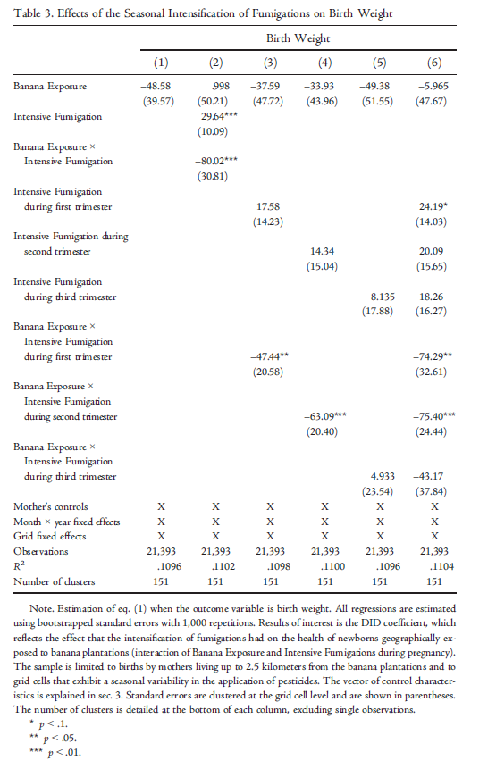

The code to replicate columns 1-6 of Table3:

```r
table3_reg1 = get_results(
    data = bananas1,
    dependent_var = "weight",
    independent_var = c("bx", "ethnic"),
    fixed_effects = c("grid", "cohort"),
    remove_var = NA,
    cluster_var = "grid",
    model_type = "ols",
    n_bootstraps = no_bootstraps,
    regression_number = 1
)
write.csv(x = table3_reg1, file = 'regressions_results/table3_reg1.csv')

table3_reg2 = get_results(
    data = bananas1,
    dependent_var = "weight",
    independent_var = c("bx*pxp", "ethnic"),
    fixed_effects = c("grid", "cohort"),
    remove_var = NA,
    cluster_var = "grid",
    model_type = "ols",
    n_bootstraps = no_bootstraps,
    regression_number = 3
)
write.csv(x = table3_reg2, file = 'regressions_results/table3_reg2.csv')

table3_reg3 = get_results(
    data = bananas1,
    dependent_var = "weight",
    independent_var = c("bx*pxt1", 'ethnic)'),
    fixed_effects = c("grid", "cohort"),
    remove_var = NA,
    cluster_var = "grid",
    model_type = "ols",
    n_bootstraps = no_bootstraps,
    regression_number = 3)
write.csv(x = table3_reg3, file = 'regressions_results/table3_reg3.csv')

table3_reg4 = get_results(
    data = bananas1,
    dependent_var = "weight",
    independent_var = c("bx*pxt2", 'ethnic'),
    fixed_effects = c("grid", "cohort"),
    remove_var = NA,
    cluster_var = "grid",
    model_type = "ols",
    n_bootstraps = no_bootstraps,
    regression_number = 4)
write.csv(x = table3_reg4, file = 'regressions_results/table3_reg4.csv')

table3_reg5 = get_results(
    data = bananas1,
    dependent_var = "weight",
    independent_var = c("bx*pxt3",'ethnic'),
    fixed_effects = c("grid", "cohort"),
    remove_var = NA,
    cluster_var = "grid",
    model_type = "ols",
    n_bootstraps = no_bootstraps,
    regression_number = 5)
write.csv(x = table3_reg5, file = 'regressions_results/table3_reg5.csv')

table3_reg6 = get_results(
    data = bananas1,
    dependent_var = "weight",
    independent_var = c("bx*pxt1", 'bx*pxt2', 'bx*pxt3', 'ethnic'),
    fixed_effects = c("grid", "cohort"),
    remove_var = NA,
    cluster_var = "grid",
    model_type = "ols",
    n_bootstraps = no_bootstraps,
    regression_number = 6)
write.csv(x = table3_reg6, file = 'regressions_results/table3_reg6.csv')
```

### Table 4

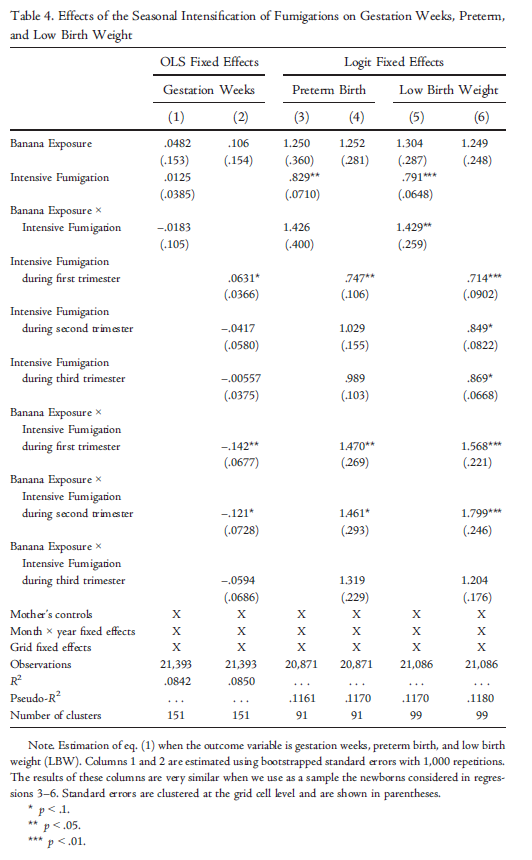

We ran this code to replicate columns 1-6 of Table 4:

```r
table4_reg1 = get_results(
    data = bananas1,
    dependent_var = "gweeks",
    independent_var = c('bx*pxp','ethnic'),
    fixed_effects = c("grid", "cohort"),
    remove_var = NA,
    cluster_var = "grid",
    model_type = "ols",
    n_bootstraps = no_bootstraps,
    regression_number = 1)
write.csv(x = table4_reg1, file = 'regressions_results/table4_reg1.csv')

table4_reg2 = get_results(
    data = bananas1,
    dependent_var = "gweeks",
    independent_var = c('bx*pxt1','bx*pxt2','bx*pxt3','ethnic'),
    fixed_effects = c("grid", "cohort"),
    remove_var = NA,
    cluster_var = "grid",
    model_type = "ols",
    n_bootstraps = no_bootstraps,
    regression_number = 2)
write.csv(x = table4_reg2, file = 'regressions_results/table4_reg2.csv')

table4_reg3 = get_results(
    data = bananas1,
    dependent_var = "preterm",
    independent_var = c('bx*pxp','ethnic'),
    fixed_effects = c("grid", "cohort"),
    remove_var = NA,
    cluster_var = "grid",
    model_type = "logit",
    n_bootstraps = no_bootstraps,
    regression_number = 3)
write.csv(x = table4_reg3, file = 'regressions_results/table4_reg3.csv')

table4_reg4 = get_results(
    data = bananas1,
    dependent_var = "preterm",
    independent_var = c('bx*pxt1','bx*pxt2','bx*pxt3','ethnic'),
    fixed_effects = c("grid", "cohort"),
    remove_var = NA,
    cluster_var = "grid",
    model_type = "logit",
    n_bootstraps = no_bootstraps,
    regression_number = 4)
write.csv(x = table4_reg4, file = 'regressions_results/table4_reg4.csv')

table4_reg5 = get_results(
    data = bananas1,
    dependent_var = "lbw",
    independent_var = c('bx*pxp','ethnic'),
    fixed_effects = c("grid", "cohort"),
    remove_var = NA,
    cluster_var = "grid",
    model_type = "logit",
    n_bootstraps = no_bootstraps,
    regression_number = 5)
write.csv(x = table4_reg5, file = 'regressions_results/table4_reg5.csv')

table4_reg6 = get_results(
    data = bananas1,
    dependent_var = "lbw",
    independent_var = c('bx*pxt1','bx*pxt2','bx*pxt3','ethnic'),
    fixed_effects = c("grid", "cohort"),
    remove_var = NA,
    cluster_var = "grid",
    model_type = "logit",
    n_bootstraps = no_bootstraps,
    regression_number = 6)
write.csv(x = table4_reg6, file = 'regressions_results/table4_reg6.csv')
```

### Table 5

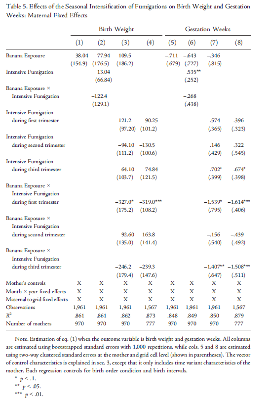

```r
birth_interval = c("birth_interval1","birth_interval2","birth_interval3")

table5_reg1 = get_results(
    data = bananas2,
    dependent_var = "weight",
    independent_var = c('bx',birth_interval),
    fixed_effects = c('cohort',"mfeid*grid"),
    remove_var = NA,
    cluster_var = "grid",
    model_type = "ols",
    n_bootstraps = no_bootstraps,
    regression_number = 1)
write.csv(x = table5_reg1, file = 'regressions_results/table5_reg1.csv')

table5_reg2 = get_results(
    data = bananas2,
    dependent_var = "weight",
    independent_var = c('bx*pxp',birth_interval),
    fixed_effects = c('cohort',"mfeid*grid"),
    remove_var = NA,
    cluster_var = "grid",
    model_type = "ols",
    n_bootstraps = no_bootstraps,
    regression_number = 2)
write.csv(x = table5_reg2, file = 'regressions_results/table5_reg2.csv')

table5_reg3 = get_results(
    data = bananas2,
    dependent_var = "weight",
    independent_var = c('bx*pxt1','bx*pxt2','bx*pxt3',birth_interval),
    fixed_effects = c('cohort',"mfeid*grid"),
    remove_var = NA,
    cluster_var = "grid",
    model_type = "ols",
    n_bootstraps = no_bootstraps,
    regression_number = 3)
write.csv(x = table5_reg3, file = 'regressions_results/table5_reg3.csv')

table5_reg4 = get_results(
    data = bananas2[bananas2$stay_mom > 0,],
    dependent_var = "weight",
    independent_var = c('bx*pxt1','bx*pxt2','bx*pxt3',birth_interval),
    fixed_effects = c('cohort',"mfeid*grid"),
    remove_var = NA,
    cluster_var = "grid",
    model_type = "ols",
    n_bootstraps = no_bootstraps,
    regression_number = 4)
write.csv(x = table5_reg4, file = 'regressions_results/table5_reg4.csv')

table5_reg5 = get_results(
    data = bananas2,
    dependent_var = "gweeks",
    independent_var = c('bx',birth_interval),
    fixed_effects = c('cohort',"mfeid*grid"),
    remove_var = NA,
    cluster_var = "grid",
    model_type = "ols",
    n_bootstraps = no_bootstraps,
    regression_number = 5)
write.csv(x = table5_reg5, file = 'regressions_results/table5_reg5.csv')

table5_reg6 = get_results(
    data = bananas2,
    dependent_var = "gweeks",
    independent_var = c('bx*pxp',birth_interval),
    fixed_effects = c('cohort',"mfeid*grid"),
    remove_var = NA,
    cluster_var = "grid",
    model_type = "ols",
    n_bootstraps = no_bootstraps,
    regression_number = 6)
write.csv(x = table5_reg6, file = 'regressions_results/table5_reg6.csv')

table5_reg7 = get_results(
    data = bananas2,
    dependent_var = "gweeks",
    independent_var = c('bx*pxt1','bx*pxt2','bx*pxt3',birth_interval),
    fixed_effects = c('cohort',"mfeid*grid"),
    remove_var = NA,
    cluster_var = "grid",
    model_type = "ols",
    n_bootstraps = no_bootstraps,
    regression_number = 7)
write.csv(x = table5_reg7, file = 'regressions_results/table5_reg7.csv')

table5_reg8 = get_results(
    data = bananas2[bananas2$stay_mom > 0,],
    dependent_var = "gweeks",
    independent_var = c('bx*pxt1','bx*pxt2','bx*pxt3',birth_interval),
    fixed_effects = c('cohort',"mfeid*grid"),
    remove_var = NA,
    cluster_var = "grid",
    model_type = "ols",
    n_bootstraps = no_bootstraps,
    regression_number = 8)
write.csv(x = table5_reg8, file = 'regressions_results/table5_reg8.csv')
```

### Table 6

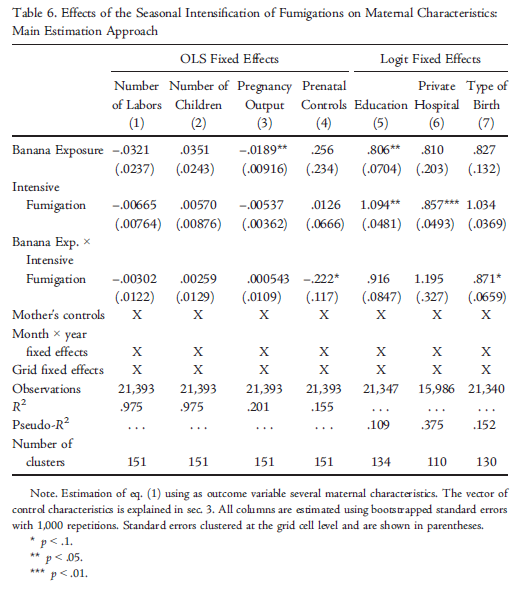

```r
table6_reg1 = get_results(
    data = bananas1,
    dependent_var = "labors",
    independent_var = c('bx*pxp','ethnic'),
    fixed_effects = c("grid", "cohort"),
    remove_var = c('labors'),
    cluster_var = "grid",
    model_type = "ols",
    n_bootstraps = no_bootstraps,
    regression_number = 1)
write.csv(x = table6_reg1, file = 'regressions_results/table6_reg1.csv')


table6_reg2 = get_results(
    data = bananas1,
    dependent_var = "nchild",
    independent_var = c('bx*pxp','ethnic'),
    fixed_effects = c("grid", "cohort"),
    remove_var = c('nchild'),
    cluster_var = "grid",
    model_type = "ols",
    n_bootstraps = no_bootstraps,
    regression_number = 2)
write.csv(x = table6_reg2, file = 'regressions_results/table6_reg2.csv')

table6_reg3 = get_results(
    data = bananas1,
    dependent_var = "nbl",
    independent_var = c('bx*pxp','ethnic'),
    fixed_effects = c("grid", "cohort"),
    remove_var = c('nbl'),
    cluster_var = "grid",
    model_type = "ols",
    n_bootstraps = no_bootstraps,
    regression_number = 3)
write.csv(x = table6_reg3, file = 'regressions_results/table6_reg3.csv')

table6_reg4 = get_results(
    data = bananas1,
    dependent_var = "visits",
    independent_var = c('bx*pxp','ethnic'),
    fixed_effects = c("grid", "cohort"),
    remove_var = c('visits'),
    cluster_var = "grid",
    model_type = "ols",
    n_bootstraps = no_bootstraps,
    regression_number = 4)
write.csv(x = table6_reg4, file = 'regressions_results/table6_reg4.csv')

table6_reg5 = get_results(
    data = bananas1,
    dependent_var = "educ",
    independent_var = c('bx*pxp','ethnic'),
    fixed_effects = c("grid", "cohort"),
    remove_var = c('educ'),
    cluster_var = "grid",
    model_type = "logit",
    n_bootstraps = no_bootstraps,
    regression_number = 5)
write.csv(x = table6_reg5, file = 'regressions_results/table6_reg5.csv')

table6_reg6 = get_results(
    data = bananas1,
    dependent_var = "private",
    independent_var = c('bx*pxp','ethnic'),
    fixed_effects = c("grid", "cohort"),
    remove_var = c('private'),
    cluster_var = "grid",
    model_type = "logit",
    n_bootstraps = no_bootstraps,
    regression_number = 6)
write.csv(x = table6_reg6, file = 'regressions_results/table6_reg6.csv')

table6_reg7 = get_results(
    data = bananas1,
    dependent_var = "tlabor",
    independent_var = c('bx*pxp','ethnic'),
    fixed_effects = c("grid", "cohort"),
    remove_var = c('tlabor'),
    cluster_var = "grid",
    model_type = "logit",
    n_bootstraps = no_bootstraps,
    regression_number = 7)
write.csv(x = table6_reg7, file = 'regressions_results/table6_reg7.csv')
```